# Our Response to Climate Change: Hong Kong 2100 - Renewable Energy & Transportation

Prepared by Dr. Hongshan Guo and Class

2025-02-19

# Last Week’s Strategy: The Barnum Slide

## Quick Callback

Last week’s strategy: **The Barnum Slide**

*Statements that feel specific but apply to everyone create false intimacy.*

**Anyone try it?** Did you write a sentence that felt personal but was actually universal?

Did faces react?

## Something You Took Away Last Week

Week 3 gave you a tool: **Life Cycle Assessment.**

You learned that where you **draw the system boundary** changes the entire answer.

- Cotton tote vs. plastic bag? Depends on *how many times you reuse it.*
- Beyond Burger vs. chicken? Depends on *whether you count land use.*
- Organic cotton vs. conventional? Depends on *which impact you measure.*

That’s not just an LCA skill — that’s **systems thinking.** And you’ll need it again today.

## From Products → Energy Systems

Last week: *“Is this product really green?”*

This week: *“Is this energy source really clean?”*

**Same question. Bigger system boundary.**

Solar panels look perfect — until you widen the boundary to include **timing** (when the sun shines vs. when you need power), **storage** (where does the excess go?), and **grid stability** (who fills the gap at sunset?).

This is your portable toolkit — system-boundary thinking works for fashion, energy, food, transport. Every week builds on it.

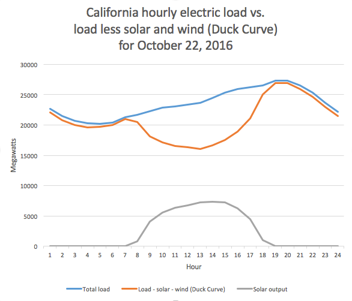

The Duck Curve — California ISO, 2016. The shape that changed the energy debate.

*This one graph explains why solar energy alone can’t save us.*

# This Week’s Battlefield

## Two Sides. Two Energy Futures.

PRO-CLIMATE

= Transition Now

= “Renewables at any cost”

PRO-DEVELOPMENT

= Pragmatic Transition

= “Don’t wreck the economy”

## The Core Tension

| PRO-CLIMATE | PRO-DEVELOPMENT |
| --- | --- |
| Rapid decarbonization | Gradual transition |
| Accept higher costs now | Keep energy affordable |
| Government mandates | Market incentives |
| End fossil fuels immediately | Bridge fuels (gas) acceptable |
| Future generations | Current livelihoods |

**This tension drives every energy policy debate.**

# But First: A Test of Your Instincts

## Quick Poll

Which energy source has killed the **most** people per unit of electricity produced?

1. Nuclear
2. Coal
3. Solar
4. Wind

**Vote now.**

## The Answer (You Probably Got It Right)

Coal kills approximately **24.6 people per TWh** of electricity produced.

That includes mining accidents, air pollution, respiratory disease.

Nuclear? **0.03 deaths per TWh.** Even including Chernobyl and Fukushima.

OK, that one was easy. But here’s where it gets weird…

*Source: Markandya & Wilkinson (2007) The Lancet; Our World in Data (2023)*

## Wait — Solar and Wind Kill People?

Solar: **0.05 deaths per TWh.** Wind: **0.04 deaths per TWh.**

Both are *higher* than nuclear.

Rooftop installation falls. Manufacturing accidents. Mining for rare earth minerals.

**The point:** The energy source the public fears most (nuclear) is statistically the safest. The one they trust most (solar) is slightly more dangerous per kWh. Perception ≠ reality.

*Source: Markandya & Wilkinson (2007); Sovacool et al. (2016) Journal of Cleaner Production*

# The Renewable Energy Landscape

## Six Sources, One Table

| Source | Best For | Biggest Problem | HK Viability |
| --- | --- | --- | --- |
| **Solar** | Rooftops, building façades | Intermittent; storage needed; Duck Curve | **Medium** — limited rooftop space |
| **Wind** | Offshore (South China Sea) | High cost; marine/bird impact | **Medium** — offshore potential |
| **Hydropower** | Dams, river systems | Ecosystem disruption; land required | **Very Low** — no rivers |
| **Geothermal** | Volcanic/tectonic regions | Drilling cost; seismic risk | **Very Low** — wrong geology |
| **Biomass** | Waste processing | Deforestation; emissions from combustion | **Low** — limited feedstock |
| **Tidal/Wave** | Coastal areas with strong currents | High cost; early-stage technology | **Low-Medium** — research stage |

For Hong Kong, only three matter in practice: **Solar, Wind, and Waste-to-Energy.**

# The Duck Curve: Solar’s Achilles Heel

## The Duck Curve: Three Problems in One

The Belly (Midday)

Solar floods the grid when demand is moderate. Supply > demand. No battery storage at scale. Wholesale prices go **negative** — California pays Arizona to absorb the excess because it’s physically easier than shutting off thousands of rooftop panels.

The Neck (4–7 PM Ramp)

The Tail (Evening Peak)

All that solar capacity contributes **nothing** at the moment demand is highest. The evening peak is met almost entirely by fossil fuels — just like before solar existed.

The cruel irony: the more solar you build, the deeper the belly and the steeper the ramp. More solar makes the duck *worse* — until storage catches up.

# Case Studies: Real People, Real Consequences

## California: The Paradox on Maria’s Roof

**Maria** in San Diego installed rooftop solar in 2015. Her electricity bill dropped from **$200/month to $12**. She told everyone: *“Solar pays for itself.”*

Then San Diego Gas & Electric changed the rules. **Time-of-use pricing** meant Maria was selling power at midday — when it was worth almost nothing — and buying it back at peak evening rates.

Her savings dropped to **$40/month**. Her panels still worked perfectly. The economics didn’t.

Meanwhile, California was **paying Arizona to take its excess solar power** — negative wholesale prices. The grid couldn’t handle what it asked for.

*Governor Schwarzenegger said “solar panels on every rooftop.” Nobody mentioned what happens when every rooftop turns on at the same time.*

*Sources: CAISO Duck Curve data; CPUC NEM 3.0 proceedings; San Diego Union-Tribune reporting*

## Germany: Klaus and the Dead Town

**Klaus** worked in the lignite mines of Schwarze Pumpe, Lausitz, for 30 years. His father mined there. His grandfather too. Three generations of brown coal.

The Energiewende shut his mine. The government promised retraining. Klaus was 55.

Five years later: **60% of retrained workers** in the Lausitz region were unemployed or in worse-paying jobs. The town’s population **halved**. The local school closed. The pub closed.

And Germany’s CO₂ emissions? **Barely changed for years** — because Berlin simultaneously shut down zero-carbon nuclear plants and temporarily burned *more coal* to fill the gap.

*Klaus lost his livelihood for a transition that, for a decade, didn’t even reduce emissions.*

*Sources: Agora Energiewende; IW Köln regional labor studies; Clean Energy Wire; UBA emissions data*

## Ontario: The Bill That Brought Down a Government

The **Henderson family** in rural Ontario had a $120/month electricity bill in 2009. That year, Premier Dalton McGuinty signed the **Green Energy Act**. *“We will create a new industry and thousands of jobs.”*

Feed-in tariffs guaranteed solar producers **80 cents per kWh** — when market price was 3–5 cents. Someone had to pay the difference. The Hendersons did.

By 2016, their bill was **$250/month**. The “Global Adjustment” charge — the hidden cost of renewable subsidies — was *larger than the cost of actual electricity*.

Ontario lost **300,000 manufacturing jobs** (energy costs were one factor). In 2018, the governing Liberals won **one seat**. The worst electoral defeat in the province’s history.

*Sources: Ontario Energy Board rate data; Ontario Auditor General (2015); Statistics Canada*

## What Do These Stories Have in Common?

None of them are anti-renewable.

All of them are **anti-simplicity**.

- California proves: **timing and storage matter** as much as generation.
- Germany proves: **sequencing matters** — don’t kill nuclear before renewables can replace it.
- Ontario proves: **cost distribution matters** — who pays for the transition?

The transition is necessary. The question is how to not destroy people along the way.

# Bringing It Home: Hong Kong

Castle Peak Power Station, Tuen Mun — one of the largest coal-fired plants in Asia.

## “Why Tuen Mun Again?”

In 2007, when the government proposed building *another* polluting facility in Tuen Mun, District Councillor **Lung Shui-hing** stood up:

> *“Why Tuen Mun again? The government is treating the district like a garbage dump where all the unwanted facilities are found.”*

All 13 councillors voted unanimously against. They noted Tuen Mun already housed: Castle Peak Power Station, a recycling park, a steel mill, oil tanks, and a landfill.

Government officials later acknowledged that **easterly winds — which carry pollutants away from the main urban areas — influenced site selection.**

The pollution isn’t accidental. The location was chosen because the people living downwind were deemed less likely to complain.

*Source: SCMP, August 18, 2007*

## Mrs Ho Can’t Stop Coughing

**Mrs Ho**, 56, developed an airway allergy she attributes partly to Hong Kong’s air pollution. She described it to SCMP:

> *“I coughed uncontrollably, drawing odd stares and dirty looks from people around me on the street.”*

**Dr Loretta So Kit-ying**, respiratory medicine specialist: *“Nitrogen dioxide will cause irritation to the airways, leading to a range of respiratory diseases.”*

In 2015, Tuen Mun recorded **395 hours** of “high” or above air quality readings — the **worst in Hong Kong** for the second consecutive year.

*Sources: SCMP, Victor Ting, July 19, 2019; SCMP, Ernest Kao, November 30, 2015*

## The Price Tag on Hong Kong’s Air

3,508

premature deaths from air pollution in Hong Kong (2024)

HK$42B

economic loss from pollution-related health costs annually

550%

how much HK’s roadside NO₂ exceeds WHO guidelines

Prof **Anthony Hedley** (HKU School of Public Health): *“Probably 100 per cent of the population is exposed, at unacceptable levels, to this environmental hazard.”*

*Sources: Clean Air Network / HKU (2024 Review); Hedley Environmental Index ([hedleyindex.hku.hk](https://hedleyindex.hku.hk/en/health-economic-loss))*

## Hong Kong’s Energy Reality

| Factor | Reality |
| --- | --- |
| **Current renewable share** | ~1% (one of the lowest in developed economies) |
| **2035 target** | 7.5–10% renewables |
| **Largest clean source** | Daya Bay nuclear import (~25% of supply) |
| **Main fossil fuels** | Coal (~25%) + Natural Gas (~45%) |
| **Offshore wind potential** | Could generate **32%** of HK’s electricity |
| **Solar rooftop potential** | Could generate another **16%** |
| **Government’s plan (CLP, 2024)** | *“Mostly nuclear”* — import from Guangdong |

HK’s renewable potential could cover nearly **half** its electricity. The target is 7.5–10%. CLP says the future is nuclear imports. *The city chose to outsource its energy conscience.*

*Sources: EMSD; CLP & HK Electric annual reports; Energy Connects, August 2024*

# Today’s Debate

## The Motion

**“Hong Kong should double its nuclear energy imports from mainland China to achieve carbon neutrality, rather than investing in local renewable energy.”**

PRO-CLIMATE argues **against**. PRO-DEVELOPMENT argues **for**.

*(Or does it? Which side are you really on?)*

## Why This Motion Is Hard

Against (PRO-CLIMATE?)

- Energy dependence on mainland China
- Nuclear waste and accident risk
- HK has wind + solar potential (48%)
- Local jobs in renewable sector
- **But…** nuclear is zero-carbon. Opposing it means more fossil fuels *now*.

For (PRO-DEVELOPMENT?)

- Nuclear is safest per kWh (0.03 deaths/TWh)
- Reliable baseload — no Duck Curve problem
- HK has no space for large-scale renewables
- Proven, affordable, already 25% of supply
- **But…** you’re outsourcing your energy future to another jurisdiction.

# Building Your Energy Spectacle

## The Formula (Reminder)

**Fact** + **Human Story** + **Stakes** = **Spectacle**

Weak

“Solar energy costs have decreased”

Better

“Solar costs dropped 89% since 2010”

Spectacle

“In 2010, solar was for hippies. In 2025, it’s cheaper than coal. The oil companies knew — and lied.”

## PRO-CLIMATE: Make It Personal

**Don’t say:** “Fossil fuels cause emissions.”

**Say:** “Mrs Ho coughs uncontrollably on the street and strangers give her dirty looks. She lives downwind from Castle Peak. You’re paying for cheap electricity with her lungs.”

**Don’t say:** “We need renewable energy mandates.”

**Say:** “Germany did it. California did it. Hong Kong says ‘too expensive.’ Is your child’s health too expensive?”

## PRO-DEVELOPMENT: Paint the Picture

**Don’t say:** “Energy transitions are complex.”

**Say:** “Ontario rushed renewables. Electricity bills doubled. Factories closed. Workers lost jobs. The government was wiped out. One seat. Is that the transition you want?”

**Don’t say:** “We need reliable baseload power.”

**Say:** “Germany spent €500 billion on renewables. When the wind doesn’t blow, they import nuclear from France. Klaus lost his job, his pension, his town. The carbon needle barely moved.”

## Still Unsure About Your Persona?

If you’re still deciding on some traits, here are some starting points — mix, match, or invent your own:

**Lean PRO-CLIMATE?** Try being a…

- Parent living downwind from Castle Peak
- Youth activist who just read the IPCC report
- Renewable energy entrepreneur
- Doctor treating pollution-related illness

**Lean PRO-DEVELOPMENT?** Try being a…

- Grid engineer keeping the lights on
- Factory owner watching electricity bills climb
- Government official balancing budgets
- Coal worker whose town depends on the plant

Ask yourself: **What do I stand to lose?** That’s where your story begins.

## Remember: Fact-Check Your Stories

OK to Say

NOT OK

- “Renewables can power everything now” *(ignores intermittency)*
- “Green energy destroys economies” *(exaggeration)*
- “Nuclear is perfectly safe” *(overstated — low risk ≠ no risk)*
- “Oil companies are literally killing people” *(unverifiable as stated)*

# Group Assignment Time!

## Presentation Countdown

00:00

# The Persuasion Playbook | Strategy #3

## Sensory Hijack

People holding a **warm cup of coffee** rated strangers as more trustworthy than those holding iced drinks.

They had no idea the cup mattered.

## The Science

This is **Embodied Cognition** (Williams & Bargh, 2008).

The body doesn’t just receive information — it **shapes judgment**.

- Physical warmth → social warmth
- Heaviness → seriousness
- Roughness → difficulty

**The brain takes sensory shortcuts constantly.**

## You Just Saw It — In the Energy Debate

The arguments that landed today weren’t abstract policy statements.

They made you **feel something in your body**.

Not “coal combustion produces particulate matter affecting respiratory health.”

But: *“Mrs Ho coughs uncontrollably on the street. Strangers give her dirty looks. She doesn’t know how to explain that the air itself is making her sick.”*

Not “energy transitions have economic costs.”

But: *“Klaus is 55. His mine closed. His pension vanished. His town is dying.”*

That’s sensory hijack. Body-first, logic second.

## Next Week’s Challenge

**Make your audience physically uncomfortable — on purpose.**

One image. One sentence. Body-first.

# Appendix: Reference & Self-Study Material

## Appendix: Videos to Watch on Your Own

**Do We Need Nuclear Energy to Stop Climate Change?**

[video not shown]

*Kurzgesagt (~10 min). Concludes nuclear and renewables should be partners, not opponents.*

## Appendix: The Duck Curve Explained (Video)

[video not shown]

*Vox (~5 min) — Visual deep-dive into why more solar creates grid problems.*

## Appendix: Can YOU Fix Climate Change?

[video not shown]

*Kurzgesagt (~15 min). The concept of “personal carbon footprint” was invented by BP’s ad agency in 2005.*

## Appendix: More “Wait, What?” Energy Facts

| Topic | “Wait, What?” Opening |
| --- | --- |
| Nuclear safety | “Nuclear has killed fewer people per kWh than solar. Yes, including Chernobyl.” |
| Solar limits | “California has so much solar it pays other states to take it — then fires up gas plants at sunset.” |
| Wind disposal | “A single turbine blade is longer than a 747 wing. It goes to landfill.” |
| HK EVs | “Your Tesla charged in HK might be dirtier than a Prius — the grid is 70% fossil.” |
| Germany | “Germany spent €500B on green energy. Its CO₂ barely changed for a decade.” |
| Scale | “More solar hits the Earth in one hour than humanity uses in a year.” |
| Carbon footprint | “Your ‘personal carbon footprint’? BP’s ad agency invented that in 2005.” |

## Appendix: Local Energy Projects

## Local Hydropower Plant

[video not shown]

## [Local Geothermal Project](https://re.emsd.gov.hk/english/energy/thermal/ther_re.html)

## [Tidal Farm @ CityU](https://www.cityu.edu.hk/see_mer/tidal-Intro.htm)

## Appendix: Anita Tang’s Rooftop Solar

**Anita Tang** (56) and her architect husband **Stephen** (62) installed solar panels at Fairview Park, Yuen Long, in October 2018.

- Installation cost: **HK$180,000**
- Monthly earnings from CLP Feed-in Tariff: **HK$2,500–3,000**
- Expected payback: ~6 years
- Approval took **two months** instead of two weeks

Anita: *“Some suppliers said they were registered, but we couldn’t find their address.”*

Village house owner **Newman Lau Man-choi** in Clear Water Bay can only use half his rooftop — by regulation.

*Sources: SCMP, Athena Chan, July 14, 2019; HKFP, December 25, 2018*

## Appendix: Detailed Renewable Energy Data

**Solar**: Abundant sunlight; low operating costs. But: high initial costs, requires significant space, production variability. Duck Curve problem at scale.

**Wind**: Clean and renewable; offshore potential. But: high installation/maintenance costs, marine and bird life impact. Blade disposal problem.

**Hydropower**: Reliable, low GHG. But: ecosystem disruption, zero feasibility in HK.

**Geothermal**: Consistent, small footprint. But: wrong geology for HK. [EMSD project](https://re.emsd.gov.hk/english/energy/thermal/ther_re.html) is ground-source heat pumps only.

**Biomass**: Uses organic waste. But: deforestation risk, combustion emissions.

**Tidal/Wave**: Predictable, minimal visual impact. But: high cost, early-stage. [CityU research](https://www.cityu.edu.hk/see_mer/tidal-Intro.htm) exploring potential.

## Appendix: Full Sources

| Claim | Source |
| --- | --- |
| Nuclear 0.03 deaths/TWh | Markandya & Wilkinson (2007) The Lancet |
| Solar 0.05 deaths/TWh | Sovacool et al. (2016) Journal of Cleaner Production |
| Germany CO₂ stagnation 2009-2019 | Agora Energiewende; UBA |
| Germany €500B+ Energiewende cost | DIW Berlin; BMWi federal reports |
| Ontario bills doubled | Ontario Energy Board; Auditor General (2015) |
| California negative pricing | CAISO market reports |
| HK grid ~70% fossil | CLP & HK Electric annual reports (2023) |
| HK air pollution 3,508 deaths | Clean Air Network / HKU (2024) |
| Wind blade landfill | Bloomberg (2020); Liu & Barlow (2017) |
| Solar costs dropped 89% | IRENA Renewable Power Generation Costs (2023) |
| CLP “mostly nuclear” future | Energy Connects, August 2024 |
| HK offshore wind 32% potential | EMSD estimates |

*Note: Energy data evolves rapidly. Always check for most recent reports.*